# Práctica Deep Learning - Santiago Bedoya Builes

## **4. Generación, inserción y eliminación de características**

¿Qúe columnas tienen datos nulos?

```python
train.isnull().any()
```

```
ID                        False
Host Since                False
Host Response Rate         True
Neighbourhood              True
Neighbourhood Cleansed    False
Property Type             False
Room Type                 False
Accommodates              False
Bathrooms                  True
Bedrooms                   True
Bed Type                  False
Price                     False
Security Deposit           True
Cleaning Fee               True
Guests Included           False
Extra People              False
Minimum Nights            False
Maximum Nights            False
Availability 365          False
Number of Reviews         False
Cancellation Policy       False
dtype: bool
```

```python
miss_response = len(train['Host Response Rate']) - train['Host Response Rate'].count()

print(f'Existen {miss_response} registros perdidos')
```

```
Existen 678 registros perdidos
```

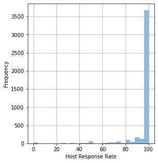

```python
plt.figure(figsize=(15, 5))
plt.subplot(1,3,1)
train['Host Response Rate'].plot.hist(alpha=0.5, bins=25, grid = True)
plt.xlabel('Host Response Rate')
```

```python
import statistics

moda = statistics.mode(train['Host Response Rate'])

cant_datos = train['Host Response Rate'].value_counts()
cant_moda = cant_datos[moda]

porcentaje_moda = 100 * ( cant_moda / train['Host Response Rate'].count() )

print(f'La moda del Host Response Rate es: {moda}. Con {cant_moda} datos, representando un {porcentaje_moda}% de los datos')
```

```
La moda del Host Response Rate es: 100.0. Con 3361 datos, representando un 77.06947947718413% de los datos
```

Existe la opción de imputar los datos añadiéndole la moda de los mismos, que como se encontró, es 100%.

Sin embargo, a análisis personal, considero esto algo bastante irresponsable, puesto que, no se pueden inventar datos que dependan de cada Host, que si bien, lo que dicen los datos es que la inmensa mayoría (un +- 77%) tiende a responder el 100% de las veces, reitero, eso depende de cada Host. Por otra parte, existen otras columnas que probablemente aporten más al modelo y eliminar esta columna Host Response Rate ayudará al rendimiento y bajar la dimensionalidad para darle paso a otras características *probablemente* más importantes.

```python
train.drop('Host Response Rate', axis = 1, inplace = True)
```

**Tratamiento de antiguedad del Host**

```python
from datetime import datetime

## Tratamiento de columna 'Host Since'. Deja los años totales siendo host en vez del año desde el que es host

train['Host Since'] = train['Host Since'].apply(lambda x: datetime.strptime(str(x),'%Y-%m-%d'))
train['Years Being Host'] = train['Host Since'].apply(lambda x: 2017 - x.year)

train.drop(['Host Since'], axis=1, inplace=True)
```

**Tratamiento del barrio - Columna *Neighbourhood***

```python
# Los barrios que no estén presentes. Se rellenan con 'Neighbourhood Cleansed'
train['Neighbourhood'] = np.where(train['Neighbourhood'].isnull(),train['Neighbourhood Cleansed'],train['Neighbourhood'])
train.drop('Neighbourhood Cleansed', axis = 1, inplace = True)
```

**Tratamiento de variables numéricas**

```python
dummie = ['Bathrooms', 'Bedrooms', 'Security Deposit', 'Cleaning Fee', 'Price']

print(train[dummie].describe()) ,
print(train[dummie].info())
```

```
         Bathrooms     Bedrooms  Security Deposit  Cleaning Fee        Price
count  5015.000000  5026.000000       2125.000000   2861.000000  5039.000000
mean      1.266102     1.300438        181.111529     29.335897    66.514586
std       0.617866     0.818728        102.506990     22.145910    64.050587
min       0.000000     0.000000         70.000000      5.000000    10.000000
25%       1.000000     1.000000        100.000000     15.000000    30.000000
50%       1.000000     1.000000        150.000000     25.000000    50.000000
75%       1.000000     1.000000        200.000000     35.000000    80.000000
max       8.000000    10.000000        900.000000    200.000000   750.000000
<class 'pandas.core.frame.DataFrame'>
Int64Index: 5039 entries, 5616 to 40
Data columns (total 5 columns):
 #   Column            Non-Null Count  Dtype
---  ------            --------------  -----
 0   Bathrooms         5015 non-null   float64
 1   Bedrooms          5026 non-null   float64
 2   Security Deposit  2125 non-null   float64
 3   Cleaning Fee      2861 non-null   float64
 4   Price             5039 non-null   float64
dtypes: float64(5)
memory usage: 236.2 KB
None
```

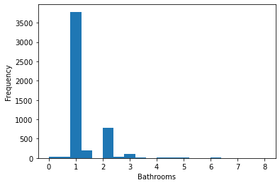

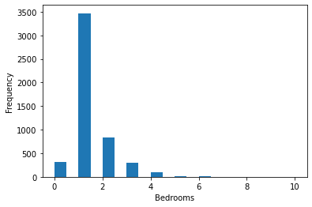

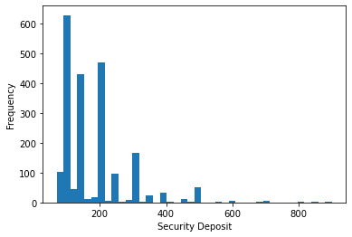

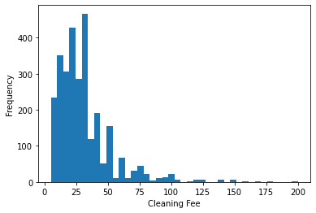

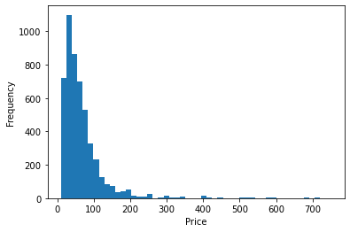

```python
train['Bathrooms'].plot.hist(bins = 20)
plt.xlabel('Bathrooms')
plt.show()

train['Bedrooms'].plot.hist(bins = 20)
plt.xlabel('Bedrooms')
plt.show()

train['Security Deposit'].plot.hist(bins = 40)
plt.xlabel('Security Deposit')
plt.show()

train['Cleaning Fee'].plot.hist(bins = 40)
plt.xlabel('Cleaning Fee')
plt.show()

train['Price'].plot.hist(bins = 50)
plt.xlabel('Price')
plt.show()
```

```python
train.shape
```

```
(5039, 19)
```

```python
train = train.loc[train['Price']<=210]
train.shape
```

```
(4903, 19)
```

Para los valores faltantes en "Bathrooms" y "Bedrooms", es mejor ingresar su moda:

Además, estos valores los casteo a su entero que esté por debajo, menos los que sean menores a 1, a estos se les trata para que sea 1. Así que creo una pequeña función para mapear estos datos

```python
def redondeo(df):
    if df < 1:
        return int(1)
    else:
        return int(df)
```

```python
train['Bathrooms'] = train['Bathrooms'].fillna(statistics.mode(train['Bathrooms']))
train['Bedrooms'] = train['Bedrooms'].fillna(statistics.mode(train['Bedrooms']))
```

```python
train[['Bathrooms', 'Bedrooms']] = train[['Bathrooms', 'Bedrooms']].applymap(redondeo)
```

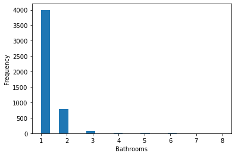

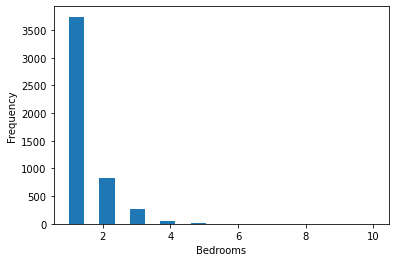

```python
train['Bathrooms'].plot.hist(bins = 20)
plt.xlabel('Bathrooms')
plt.show()

train['Bedrooms'].plot.hist(bins = 20)
plt.xlabel('Bedrooms')
plt.show()
```

```python
train['Bathrooms'].value_counts(), train['Bedrooms'].value_counts()
```

```
(1    3996
 2     782
 3      82
 4      18
 5      17
 6       6
 8       2
 Name: Bathrooms, dtype: int64,
 1     3741
 2      820
 3      266
 4       59
 5       10
 6        5
 10       2
 Name: Bedrooms, dtype: int64)
```

```python
train = train.loc[train['Bathrooms']<=5]
train = train.loc[train['Bedrooms']<=4]
train.shape
```

```
(4880, 19)
```

Tras quemarme un rato las neuronas pensando y tener varios debates filosóficos conmigo mismo considero que las filas que no tengan registro en "Security Deposit" o "Cleaning Fee" podrían reemplazarse con un valor de 0, debido a que al ser un valor tan importante para el cliente, que al Host se le olvide colocar este dato daría para muchos problemas, por tanto, valores inexistentes son 0's para mi modelo.

```python
train['Security Deposit'] = train['Security Deposit'].fillna(0)
train['Cleaning Fee'] = train['Cleaning Fee'].fillna(0)
```

```python
train = train.loc[train['Security Deposit']<=400]
train = train.loc[train['Cleaning Fee']<=120]
train.shape
```

```
(4803, 19)
```

**Tratamiento de columnas sobre noches**

> Minimum Nights

He decidido tratar los datos de "Minimum Nights" de la siguiente manera, haciendo que el mínimo de noches sea como máximo un mes, puesto que, mirando los datos; No existe un variable asociada al precio de más de un mes de renta y aunque, anteriormente la haya descartado ('Monthly Price'), lo hice porque dicha variable contiene registros insuficientes como para ser tomada en cuenta, no porque no la considere importante.

```python
media_noches = int(train['Minimum Nights'].mean())
train['Minimum Nights'] = np.where(train['Minimum Nights'] > 31, media_noches, train['Minimum Nights'])
train['Minimum Nights'].value_counts()
```

```
2     1732
1     1672
3      768
4      195
5      154
7      133
10      57
6       31
15      22
14      13
20       9
12       5
8        3
25       2
21       2
9        1
17       1
26       1
11       1
27       1
Name: Minimum Nights, dtype: int64
```

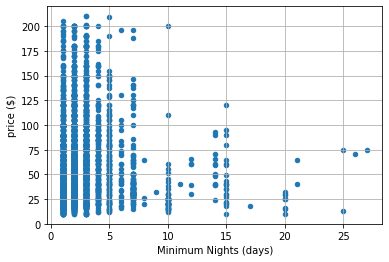

```python
train.plot(kind = 'scatter', x = 'Minimum Nights', y = 'Price', grid = True)
plt.xlabel('Minimum Nights (days)')
plt.ylabel('price ($)')
plt.show()
```

*Minimum Nights no parece tener mucha proporción directa con el precio.*

> Maximum Nights

```python
train['Maximum Nights'].value_counts()
```

```
1125      3385
30         216
365        152
7          104
15          95
10          75
60          74
90          56
3           43
5           43
20          41
31          41
180         40
14          31
28          31
```

[output cut: 85 more lines]

```python
# Hace gracia que tenga outliers tan excesivamente altos (99999, 100000, etc), que si se pasan por alto, lo más seguro es que jodan el modelo

media_mx_noches = int(train['Maximum Nights'].mean())
train['Maximum Nights'] = np.where(train['Maximum Nights'] > 1125, media_mx_noches, train['Maximum Nights'])
```

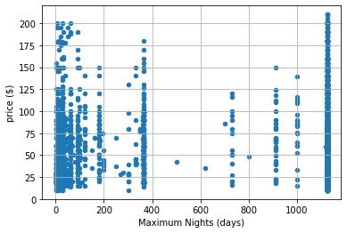

```python
train.plot(kind = 'scatter', x = 'Maximum Nights', y = 'Price', grid = True)
plt.xlabel('Maximum Nights (days)')
plt.ylabel('price ($)')
plt.show()
```

Maximum Nights tampoco parece tener mucha proporción directa con el precio

```python
categorical_columns = list(train.select_dtypes(include=['object']).columns)
print(f'La forma del dataframe en este primer corte es: {train.shape}... Hora de categorización de variables!!! Para ello, tenemos las columnas: {categorical_columns}')
```

```
La forma del dataframe en este primer corte es: (4803, 19)... Hora de categorización de variables!!! Para ello, tenemos las columnas: ['Neighbourhood', 'Property Type', 'Room Type', 'Bed Type', 'Cancellation Policy']
```

## **5. Categorización de Variables**

```python
train['Neighbourhood'].value_counts()
```

```
Embajadores                              419
Malasaña                                 311
La Latina                                284
Justicia                                 277
Sol                                      272
Palacio                                  243
Cortes                                   230
Universidad                              135
Argüelles                                129
Aluche                                    96
Trafalgar                                 88
Carabanchel                               86
Guindalera                                81
Arapiles                                  75
Goya                                      71
Recoletos                                 66
Palos do Moguer                           60
Ciudad Lineal                             58
Gaztambide                                52
Acacias                                   52
Prosperidad                               49
Cuatro Caminos                            49
Delicias                                  48
Puente de Vallecas                        45
Fuencarral-el Pardo                       44
Bellas Vistas                             43
Imperial                                  42
Almagro                                   40
Ibiza                                     39
Pacifico                                  37
Hortaleza                                 36
Palos de Moguer                           34
Lista                                     32
Rios Rosas                                31
Castillejos                               27
Berruguete                                27
Jerónimos                                 27
Puerta del Angel                          26
Chopera                                   25
Barajas                                   25
```

[output cut: 146 more lines]

```
el Baix Guinardó                           1
El Pardo                                   1
El Clot                                    1
Sant Gervasi - la Bonanova                 1
Arcos                                      1
Valdemarín                                 1
Corralejos                                 1
La Salut                                   1
Can Baro                                   1
El Camp de l'Arpa del Clot                 1
Palomas                                    1
La Paz                                     1
el Fort Pienc                              1
Artà                                       1
Name: Neighbourhood, dtype: int64
```

```python
train['Property Type'].value_counts()
```

```
Apartment             3899
House                  377
Bed & Breakfast        142
Condominium            136
Loft                    98
Other                   78
Guesthouse              21
Dorm                    14
Chalet                  14
Hostel                   8
Townhouse                5
Villa                    3
Serviced apartment       3
Boutique hotel           2
Earth House              1
Casa particular          1
Boat                     1
Name: Property Type, dtype: int64
```

```python
train['Room Type'].value_counts()
```

```
Entire home/apt    2621
Private room       2099
Shared room          83
Name: Room Type, dtype: int64
```

```python
train['Bed Type'].value_counts()
```

```
Real Bed         4702
Pull-out Sofa      80
Futon              14
Couch               5
Airbed              2
Name: Bed Type, dtype: int64
```

```python
train['Cancellation Policy'].value_counts()
```

```
strict             1728
flexible           1638
moderate           1428
super_strict_60       8
super_strict_30       1
Name: Cancellation Policy, dtype: int64
```

```python
### Función extraída de notebook de módulo de ML ###

# Esta función se encarga de eliminar registros que
# solo estén haciendo ruido en mis datos

from collections import Counter
def remove_entries(df, n, col, element_name):
    nb_counts = Counter(df[col])
    inicial = df.shape[0]

    # Borramos elementos con menos de n registros
    for i in list(nb_counts):
        if nb_counts[i] < n:
            del nb_counts[i]
            df = df[df[col] != i]

    # Dibujamos
    tdf = pd.DataFrame.from_dict(nb_counts, orient='index').sort_values(by=0)
    ax = tdf.plot(kind='bar', figsize = (22,4), color = '#007A87', alpha = 0.85)
    ax.set_title(f"{element_name} por número de registros")
    ax.set_xlabel(f"{element_name}")
    ax.set_ylabel("# de registros")

    plt.show()

    print('Número de registros eliminado: ', inicial - df.shape[0])
    print(f"Número de {element_name}s:", len(nb_counts))

    return df
```

### **5.1 Eliminación de ruido**

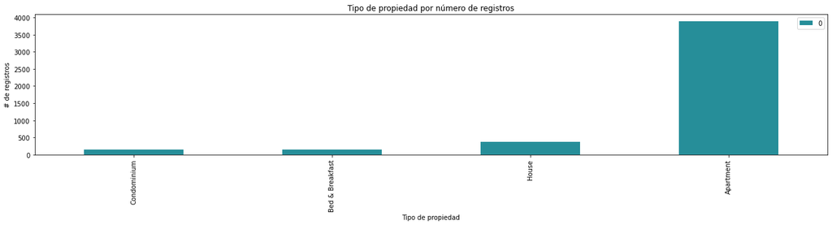

```
Número de registros eliminado:  249
Número de Tipo de propiedads: 4
```

```python
train = remove_entries(train, 100, "Property Type", "Tipo de propiedad")
```

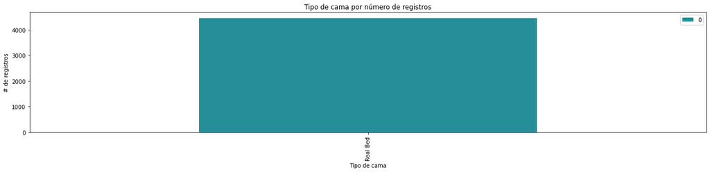

```
Número de registros eliminado:  97
Número de Tipo de camas: 1
```

```python
train = remove_entries(train, 80, "Bed Type", "Tipo de cama")
```

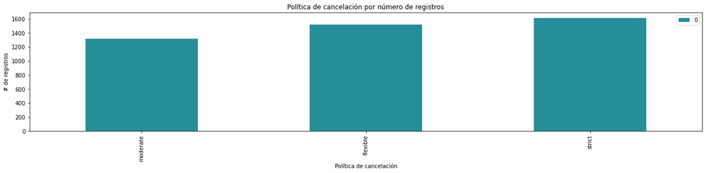

```
Número de registros eliminado:  9
Número de Política de cancelacións: 3
```

```python
train = remove_entries(train, 100, "Cancellation Policy", "Política de cancelación")
```

```python
### Función extraída de notebook de módulo de ML

# Esta función se encarga de agrupar los datos e
# insertarles la media del precio en el registro
# correspondiente

def calc_smooth_mean(df, by, on, m):
    # Compute the global mean
    mean = df[on].mean()

    # Compute the number of values and the mean of each group
    agg = df.groupby(by)[on].agg(['count', 'mean'])
    counts = agg['count']
    means = agg['mean']

    # Compute the "smoothed" means
    smooth = (counts * means + m * mean) / (counts + m)

    # Replace each value by the according smoothed mean
    return df[by].map(smooth)
```

```python
categorical = ['Neighbourhood', 'Property Type', 'Room Type', 'Bed Type', 'Cancellation Policy']

for c in categorical:
    train[c] = calc_smooth_mean(train, by=c, on='Price', m=200)

cols = train.columns.tolist()
cols.insert(0, cols.pop(cols.index('Price')))
train = train[cols]

train.fillna(train.mean(), inplace=True)

train.shape
```

```
(4448, 19)
```

```python
train.head()
```

|  | Price | ID | Neighbourhood | Property Type | Room Type | Accommodates | Bathrooms | Bedrooms | Bed Type | Security Deposit | Cleaning Fee | Guests Included | Extra People | Minimum Nights | Maximum Nights | Availability 365 | Number of Reviews | Cancellation Policy | Years Being Host |
| --- | --- | --- | --- | --- | --- | --- | --- | --- | --- | --- | --- | --- | --- | --- | --- | --- | --- | --- | --- |
| 4259 | 65.0 | 8499249 | 57.833693 | 59.239705 | 77.491353 | 4 | 1 | 1 | 57.881295 | 200.0 | 20.0 | 1 | 0 | 2 | 1125 | 349 | 10 | 58.072730 | 2 |
| 1372 | 29.0 | 4024065 | 61.097078 | 59.239705 | 34.787788 | 2 | 2 | 1 | 57.881295 | 0.0 | 15.0 | 1 | 10 | 20 | 1125 | 101 | 2 | 63.894124 | 5 |
| 4206 | 100.0 | 7447050 | 62.886060 | 59.239705 | 77.491353 | 2 | 1 | 1 | 57.881295 | 300.0 | 70.0 | 2 | 20 | 3 | 1125 | 340 | 15 | 63.894124 | 2 |
| 4645 | 110.0 | 16076949 | 54.549092 | 59.239705 | 77.491353 | 4 | 2 | 2 | 57.881295 | 200.0 | 30.0 | 1 | 0 | 1 | 1125 | 310 | 11 | 51.385392 | 4 |
| 1148 | 60.0 | 12085741 | 61.801917 | 59.239705 | 34.787788 | 2 | 2 | 1 | 57.881295 | 0.0 | 0.0 | 1 | 10 | 2 | 1125 | 311 | 27 | 58.072730 | 1 |

## **6. Selección de características**

### *Preparación de los datos*

```python
from sklearn import preprocessing

X = train.drop(['Price'], axis = 1)
ID_df = pd.DataFrame(X['ID']) # Separo los datos del ID para que este no afecte en el procesamiento
X.drop(['ID'], axis = 1, inplace = True)

y = train['Price']

feature_names = X.columns

# Normalización de los datos
scaler = preprocessing.MinMaxScaler().fit(X)

y = np.array(y).reshape(-1, 1)
y_scaler = preprocessing.MinMaxScaler().fit(y)

X_train_normalized = scaler.transform(X)
y_train_normalized = y_scaler.transform(y)
```

```
Fitting 3 folds for each of 19 candidates, totalling 57 fits
[CV] max_depth=1 .....................................................
```

```
[Parallel(n_jobs=1)]: Using backend SequentialBackend with 1 concurrent workers.
```

```
[CV] ...................................... max_depth=1, total=   0.6s
[CV] max_depth=1 .....................................................
```

```
[Parallel(n_jobs=1)]: Done   1 out of   1 | elapsed:    0.5s remaining:    0.0s
```

[output not shown]

[output cut: 56 more lines]

[output not shown]

```
[Parallel(n_jobs=1)]: Done  57 out of  57 | elapsed:  1.4min finished
```

```
best mean cross-validation score: 0.696
best parameters: {'max_depth': 17}
```

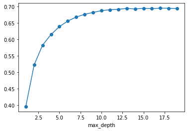

```python
# Definición de pequeño Random Forest Regressor principalmente para
# hallar el 'max deph' óptimo
from sklearn.ensemble import RandomForestRegressor
from sklearn.model_selection import GridSearchCV

maxDepth = range(1,20)
tuned_parameters = {'max_depth': maxDepth}

grid = GridSearchCV(RandomForestRegressor(n_estimators=500,
                                          max_features='log2'),
                    param_grid=tuned_parameters,
                    cv=3,
                    verbose=2)

grid.fit(X_train_normalized, y_train_normalized)

print("best mean cross-validation score: {:.3f}".format(grid.best_score_))
print("best parameters: {}".format(grid.best_params_))

scores = np.array(grid.cv_results_['mean_test_score'])
plt.plot(maxDepth,scores,'-o')
plt.xlabel('max_depth')

plt.show()
```

```python
maxDepthOptimo = 15
```

### *Preparación de test*

```python
columnas = ["Listing Url", "Thumbnail Url", "Medium Url", "Picture Url", "XL Picture Url",
           "Host ID", "Host URL", "Host Name", "Host Thumbnail Url", "Host Picture Url", "Host Neighbourhood", "Host Response Time", "Host Listings Count", "Host Total Listings Count", "Host Verifications", "Calendar Updated",
            'Host Location', "Host About", "Calculated host listings count",
            "Weekly Price", "Monthly Price",
            "Name", "Summary", "Space", "Description", "Neighborhood Overview", "Notes", "Transit", "Access", "Interaction", "House Rules", "Features", "Amenities",
            "Scrape ID", "Calendar last Scraped", "Last Scraped", "Latitude", "Longitude", "Geolocation", 'First Review', 'Last Review',]

test.drop(columnas, axis = 1, inplace = True)

test.drop('Host Acceptance Rate', axis = 1, inplace = True)

location = ['Street', 'Neighbourhood','Neighbourhood Cleansed',
            'Neighbourhood Group Cleansed','City','State', 'Zipcode',
            'Market', 'Smart Location', 'Country Code','Country']
location.remove("Neighbourhood")
location.remove("Neighbourhood Cleansed")
test.drop(location, axis = 1, inplace = True)

Availability = ['Has Availability','Availability 30', 'Availability 60', 'Availability 90','Availability 365']
test.drop('Has Availability', axis = 1, inplace = True)

Reviews = ['Number of Reviews','Review Scores Rating', 'Review Scores Accuracy',
           'Review Scores Cleanliness', 'Review Scores Checkin', 'Review Scores Communication',
           'Review Scores Location', 'Review Scores Value', 'Reviews per Month']
Reviews.remove('Number of Reviews')

test.drop(Reviews, axis = 1, inplace = True)

test.drop(['Square Feet', 'License', 'Jurisdiction Names'], axis = 1, inplace = True)

test.dropna(subset=['Host Since'], inplace = True)

test.drop('Experiences Offered', axis = 1, inplace = True)

Availability.remove('Has Availability')
Availability.remove('Availability 365')
test.drop(Availability, axis = 1, inplace = True)

test.drop('Beds', axis = 1, inplace = True)

test.drop('Host Response Rate', axis = 1, inplace = True)

from datetime import datetime

test['Host Since'] = test['Host Since'].apply(lambda x: datetime.strptime(str(x),'%Y-%m-%d'))
test['Years Being Host'] = test['Host Since'].apply(lambda x: 2017 - x.year)
test.drop(['Host Since'], axis=1, inplace=True)

test['Neighbourhood'] = np.where(test['Neighbourhood'].isnull(),test['Neighbourhood Cleansed'],test['Neighbourhood'])
test.drop('Neighbourhood Cleansed', axis = 1, inplace = True)

test = test.loc[test['Price']<=210]

def redondeo(df):
    if df < 1:
        return int(1)
    else:
        return int(df)

test['Bathrooms'] = test['Bathrooms'].fillna(statistics.mode(test['Bathrooms']))
test['Bedrooms'] = test['Bedrooms'].fillna(statistics.mode(test['Bedrooms']))
test[['Bathrooms', 'Bedrooms']] = test[['Bathrooms', 'Bedrooms']].applymap(redondeo)
test = test.loc[test['Bathrooms']<=5]
test = test.loc[test['Bedrooms']<=4]
test['Security Deposit'] = test['Security Deposit'].fillna(0)
test['Cleaning Fee'] = test['Cleaning Fee'].fillna(0)
test = test.loc[test['Security Deposit']<=400]
test = test.loc[test['Cleaning Fee']<=120]

media_noches = int(test['Minimum Nights'].mean())
test['Minimum Nights'] = np.where(test['Minimum Nights'] > 31, media_noches, test['Minimum Nights'])
media_mx_noches = int(test['Maximum Nights'].mean())
test['Maximum Nights'] = np.where(test['Maximum Nights'] > 1125, media_mx_noches, test['Maximum Nights'])

from collections import Counter
def remove_entries(df, n, col, element_name):
    nb_counts = Counter(df[col])
    inicial = df.shape[0]

    for i in list(nb_counts):
        if nb_counts[i] < n:
            del nb_counts[i]
            df = df[df[col] != i]

    print('Número de registros eliminado: ', inicial - df.shape[0])
    print(f"Número de {element_name}s:", len(nb_counts))

    return df

test = remove_entries(test, 100, "Property Type", "Tipo de propiedad")
test = remove_entries(test, 80, "Bed Type", "Tipo de cama")
test = remove_entries(test, 100, "Cancellation Policy", "Política de cancelación")

def calc_smooth_mean(df, by, on, m):
    mean = df[on].mean()

    agg = df.groupby(by)[on].agg(['count', 'mean'])
    counts = agg['count']
    means = agg['mean']
    smooth = (counts * means + m * mean) / (counts + m)
    return df[by].map(smooth)

categorical = ['Neighbourhood', 'Property Type', 'Room Type', 'Bed Type', 'Cancellation Policy']
for c in categorical:
    test[c] = calc_smooth_mean(test, by=c, on='Price', m=200)
cols = test.columns.tolist()
cols.insert(0, cols.pop(cols.index('Price')))
test = test[cols]
test.fillna(test.mean(), inplace=True)
```

```
Número de registros eliminado:  114
Número de Tipo de propiedads: 2
Número de registros eliminado:  30
Número de Tipo de camas: 1
Número de registros eliminado:  2
Número de Política de cancelacións: 3
```

```python
X_test = test.drop('Price', axis = 1)
ID_df_test = pd.DataFrame(X_test['ID'])
X_test.drop(['ID'], axis = 1, inplace = True)

y_test = test['Price']
y_test = np.array(y_test).reshape(-1, 1)

# Normalización de los datos
X_test_normalized = scaler.transform(X_test)
y_test_normalized = y_scaler.transform(y_test)
```

#### *Selección de características más importantes*

```python
randomForest = RandomForestRegressor(max_depth=maxDepthOptimo,n_estimators=500,max_features='log2')
randomForest.fit(X_train_normalized, y_train_normalized)

print("Train: ",randomForest.score(X_train_normalized, y_train_normalized))
print("Test: ",randomForest.score(X_test_normalized, y_test_normalized))
```

```
Train:  0.9379512420032965
Test:  0.6636239936711591
```

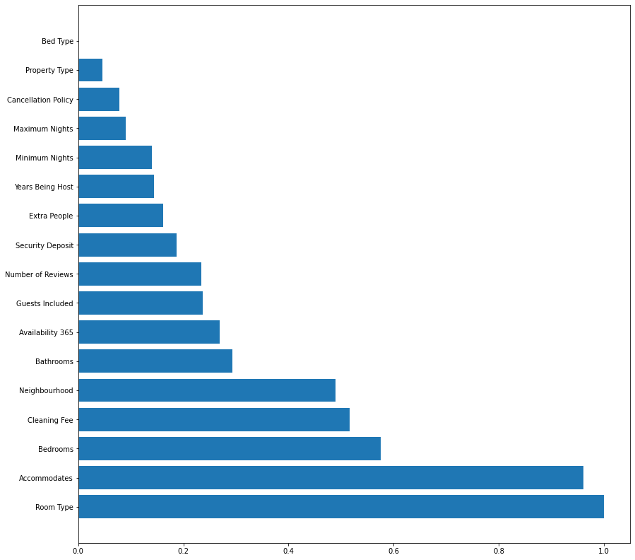

```python
importances = randomForest.feature_importances_
importances = importances / np.max(importances)

indices = np.argsort(importances)[::-1]

plt.figure(figsize=(14,14))
plt.barh(range(X_train_normalized.shape[1]),importances[indices])
plt.yticks(range(X_train_normalized.shape[1]),feature_names[indices])
plt.show()
```

**Podría simplemente basarme en esta gráfica, pero es mejor asegurarse de cuales son los datos que más influyen**

```python
### Función para elegir con certeza las características que más influyen en el precio ###

from sklearn.model_selection import KFold

X_df_norm = pd.DataFrame(X_train_normalized)
y_df_norm = pd.DataFrame(y_train_normalized)

N,Nfeatures = X.shape # Inicializar el tamaño del dataset y el número de características

rf = RandomForestRegressor(max_depth=maxDepthOptimo,n_estimators=200,max_features='log2')

kf  = KFold(n_splits=5, shuffle = True, random_state=1) # Configurar la validación cruzada K-Fold con 5 divisiones

# Listas para almacenar el error medio y la desviación estándar del error en cada iteración
cv_error = []
cv_std = []

for nfeatures in range(Nfeatures,0,-1): # Iterar sobre el número de características a seleccionar, desde todas hasta 1

    error_i = []

    for idxTrain, idxVal in kf.split(X): # Iterar sobre los índices de entrenamiento y validación generados por KFold

        # Dividir los datos en conjuntos de entrenamiento y validación según los índices
        Xt = X_df_norm.iloc[idxTrain,:]
        yt = y_df_norm.iloc[idxTrain]
        Xv = X_df_norm.iloc[idxVal,:]
        yv = y_df_norm.iloc[idxVal]

        rf.fit(Xt,yt)

        # Obtener la importancia de las características y ordenarlas
        ranking = rf.feature_importances_
        indices = np.argsort(ranking)[::-1]

        selected = indices[0:(Nfeatures-nfeatures+1)] # Seleccionar las 'nfeatures' características más importantes

        Xs = Xt.iloc[:,selected] # Filtrar el Xt para usar solo las características seleccionadas

        rf.fit(Xs,yt) # Volver a entrenar el bosque aleatorio, pero esta vez solo con las características seleccionadas

        # Calcular el error en Xv y añadirlo a la lista de errores
        error = (1.0-rf.score(Xv.iloc[:,selected],yv))
        error_i.append(error)

    # Calcular y almacenar el error medio y la desviación estándar para el número actual de características
    cv_error.append(np.mean(error_i))
    cv_std.append(np.std(error_i))

    # Imprimir el # de características seleccionadas, el error medio y su desviación estándar
    print('# features ' + str(len(selected)) + ' error ' + str(np.mean(error_i)) + ' +/- ' + str(np.std(error_i)))
```

```
# features 1 error 0.6033537256904267 +/- 0.0054490566267712745
# features 2 error 0.47602194862654007 +/- 0.010897643829112206
# features 3 error 0.4576625649018823 +/- 0.02499764861680257
# features 4 error 0.43479136255898576 +/- 0.020707558695498177
# features 5 error 0.39862863274166493 +/- 0.012348836892942782
# features 6 error 0.37057268085939044 +/- 0.015606804267532342
# features 7 error 0.3553529680351494 +/- 0.013381930882848395
# features 8 error 0.33887557725053 +/- 0.018787721657604416
# features 9 error 0.3252011302786229 +/- 0.01255631082675385
# features 10 error 0.3169329025682434 +/- 0.010906089961162723
# features 11 error 0.3005972568122012 +/- 0.011217062085660692
# features 12 error 0.29844313664463096 +/- 0.01296509335290382
# features 13 error 0.2970922626865286 +/- 0.012971783890319636
# features 14 error 0.2981181724334955 +/- 0.013482356722522702
# features 15 error 0.2974872521423966 +/- 0.014189963302199472
# features 16 error 0.29955777911722425 +/- 0.013046616427194459
# features 17 error 0.2962539288773637 +/- 0.012163150025917622
```

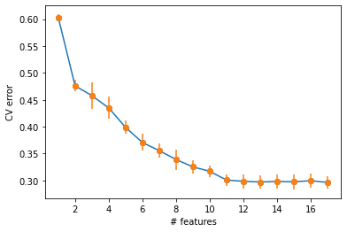

```python
plt.plot(range(1,Nfeatures+1,1),cv_error,'-o')
plt.errorbar(range(1,Nfeatures+1,1), cv_error, yerr=cv_std, fmt='o')
plt.xlabel('# features')
plt.ylabel('CV error')
plt.show()
```

```python
X_df_test_norm = pd.DataFrame(X_test_normalized)
y_df_test_norm = pd.DataFrame(y_test_normalized)

selected_features = indices[0:12] # Selección de las 12 características más importantes

randomForest = RandomForestRegressor(max_depth = maxDepthOptimo, n_estimators = 500, max_features = 'log2')

randomForest.fit(X_df_norm.iloc[:, selected_features], y_df_norm)

print("Train: ",randomForest.score(X_df_norm.iloc[:, selected_features],y_df_norm))
print("Test: ",randomForest.score(X_df_test_norm.iloc[:, selected_features],y_df_test_norm))
```

```
Train:  0.9326865063272426
Test:  0.659355815742971
```

### Entrenamiento del modelo baseline

```python
from sklearn.metrics import mean_absolute_error

tuned_parameters_2 = {"n_estimators": [100, 500]}

rf_tuned = GridSearchCV(RandomForestRegressor(), cv = 3, param_grid = tuned_parameters_2, verbose = 2)

preds = rf_tuned.fit(X_train_normalized, y_train_normalized)
y_predict = rf_tuned.predict(X_test_normalized)
rft_testing_set_score = rf_tuned.score(X_test_normalized, y_test_normalized)
rft_mean_abs_error = mean_absolute_error(y_test_normalized, y_predict)

print('Media del error en datos de test: ' + str(round(rft_mean_abs_error,3)) + '. Este resultado sirve como una Baseline para comparar con mi modelo de redes neuronales.')
```

```
Fitting 3 folds for each of 2 candidates, totalling 6 fits
[CV] n_estimators=100 ................................................
```

```
[Parallel(n_jobs=1)]: Using backend SequentialBackend with 1 concurrent workers.
```

```
[CV] ................................. n_estimators=100, total=   1.1s
[CV] n_estimators=100 ................................................
```

```
[Parallel(n_jobs=1)]: Done   1 out of   1 | elapsed:    1.0s remaining:    0.0s
```

```
[CV] ................................. n_estimators=100, total=   1.1s
[CV] n_estimators=100 ................................................
[CV] ................................. n_estimators=100, total=   1.1s
[CV] n_estimators=500 ................................................
[CV] ................................. n_estimators=500, total=   6.2s
[CV] n_estimators=500 ................................................
[CV] ................................. n_estimators=500, total=   6.2s
[CV] n_estimators=500 ................................................
[CV] ................................. n_estimators=500, total=   5.8s
```

```
[Parallel(n_jobs=1)]: Done   6 out of   6 | elapsed:   21.5s finished
```

```
Media del error en datos de test: 0.069. Este resultado sirve como una Baseline para comparar con mi modelo de redes neuronales.
```

```python
features = X_df_norm.columns
for sf in selected_features:
    print(features[sf])
```

```
2
3
5
8
0
4
13
14
9
7
10
11
```

```python
caracteristicas_seleccionadas = [feature_names[i] for i in selected_features]
caracteristicas_seleccionadas
```

```
['Room Type',
 'Accommodates',
 'Bedrooms',
 'Cleaning Fee',
 'Neighbourhood',
 'Bathrooms',
 'Availability 365',
 'Number of Reviews',
 'Guests Included',
 'Security Deposit',
 'Extra People',
 'Minimum Nights']
```

```python
X_train_final = X_df_norm.iloc[:,selected_features]
X_train_final.columns = caracteristicas_seleccionadas
```

```python
X_train_final.head()
```

|  | Room Type | Accommodates | Bedrooms | Cleaning Fee | Neighbourhood | Bathrooms | Availability 365 | Number of Reviews | Guests Included | Security Deposit | Extra People | Minimum Nights |
| --- | --- | --- | --- | --- | --- | --- | --- | --- | --- | --- | --- | --- |
| 0 | 1.0 | 0.200000 | 0.000000 | 0.166667 | 0.466267 | 0.00 | 0.956164 | 0.022422 | 0.000000 | 0.50 | 0.0 | 0.038462 |
| 1 | 0.0 | 0.066667 | 0.000000 | 0.125000 | 0.677623 | 0.25 | 0.276712 | 0.004484 | 0.000000 | 0.00 | 0.1 | 0.730769 |
| 2 | 1.0 | 0.066667 | 0.000000 | 0.583333 | 0.793488 | 0.00 | 0.931507 | 0.033632 | 0.066667 | 0.75 | 0.2 | 0.076923 |
| 3 | 1.0 | 0.200000 | 0.333333 | 0.250000 | 0.253536 | 0.25 | 0.849315 | 0.024664 | 0.000000 | 0.50 | 0.0 | 0.000000 |
| 4 | 0.0 | 0.066667 | 0.000000 | 0.000000 | 0.723273 | 0.25 | 0.852055 | 0.060538 | 0.000000 | 0.00 | 0.1 | 0.038462 |

```python
X_test_final = X_df_test_norm.iloc[:,selected_features]
X_test_final.columns = caracteristicas_seleccionadas
```

```python
X_test_final.head()
```

|  | Room Type | Accommodates | Bedrooms | Cleaning Fee | Neighbourhood | Bathrooms | Availability 365 | Number of Reviews | Guests Included | Security Deposit | Extra People | Minimum Nights |
| --- | --- | --- | --- | --- | --- | --- | --- | --- | --- | --- | --- | --- |
| 0 | 0.842123 | 0.066667 | 0.000000 | 0.250000 | 0.452733 | 0.00 | 0.079452 | 0.040359 | 0.0 | 0.000 | 0.00 | 0.038462 |
| 1 | 0.106826 | 0.200000 | 0.000000 | 0.166667 | 0.472619 | 0.00 | 0.838356 | 0.107623 | 0.0 | 0.375 | 0.12 | 0.000000 |
| 2 | 0.106826 | 0.000000 | 0.000000 | 0.125000 | 0.313483 | 0.00 | 0.835616 | 0.065022 | 0.0 | 0.500 | 0.35 | 0.038462 |
| 3 | 0.842123 | 0.266667 | 0.333333 | 0.333333 | 0.472619 | 0.00 | 0.893151 | 0.049327 | 0.2 | 0.500 | 0.15 | 0.076923 |
| 4 | 0.106826 | 0.133333 | 0.000000 | 0.183333 | 0.294187 | 0.25 | 1.000000 | 0.026906 | 0.0 | 0.000 | 0.28 | 0.000000 |

```python
y_df_norm.columns = ['Price']
y_df_norm.head()
```

|  | Price |
| --- | --- |
| 0 | 0.275 |
| 1 | 0.095 |
| 2 | 0.450 |
| 3 | 0.500 |
| 4 | 0.250 |

```python
y_df_test_norm.columns = ['Price']
y_df_test_norm.head()
```

|  | Price |
| --- | --- |
| 0 | 0.210 |
| 1 | 0.240 |
| 2 | 0.195 |
| 3 | 0.545 |
| 4 | 0.100 |

#### *Alineamiento de datos tabulares con imágenes*

```python
img_train = []
img_test = []

# Rellena img_train con las imágenes correspondientes a los IDs en ID_df
for id_ in ID_df['ID']:
    img_train.append(id_saved_imgs[id_])

# Rellena img_test con las imágenes correspondientes a los IDs en ID_df_test
for id_ in ID_df_test['ID']:
    img_test.append(id_saved_imgs[id_])

img_train = np.array(img_train)
img_test = np.array(img_test)
```

```python
# Corroboro que tanto datos tabulares como
# imágenes tengan el mismo número de registros
print(X_train_final.shape,
      y_df_norm.shape,
      X_test_final.shape,
      y_df_test_norm.shape,
      img_train.shape,
      img_test.shape)
```

```
(4448, 12) (4448, 1) (1060, 12) (1060, 1) (4448, 224, 224, 3) (1060, 224, 224, 3)
```

Aquí culmina mi selección de características.

Ahora, creación del modelo neuronal de capas Dense:

## 7.. Red Neuronal Fully Connected - Datos Tabulares

### **7.1 Primer modelo**

```python
import tensorflow as tf
from tensorflow import keras
from sklearn import metrics
from keras.models import Sequential
from keras.layers import Dense, PReLU, Dropout
from keras.optimizers import Adam
```

```python
type(X_train_final), type(y_df_norm), type(X_test_final), type(y_df_test_norm)
```

```
(pandas.core.frame.DataFrame,
 pandas.core.frame.DataFrame,
 pandas.core.frame.DataFrame,
 pandas.core.frame.DataFrame)
```

```
Train on 4003 samples, validate on 445 samples
[INFO]: Evaluando red neuronal...
Media del error en datos de test: 0.07299
```

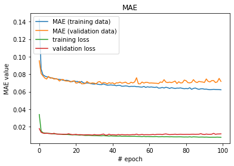

```python
X_train_final = np.array(X_train_final)
y_df_norm = np.array(y_df_norm)
X_test_final = np.array(X_test_final)
y_df_test_norm = np.array(y_df_test_norm)

lr = 0.001
n_epochs = 100
batch_size = 32


model = Sequential()
model.add(Dense(64, activation = 'relu' , input_shape = X_train_final.shape[1:]))
model.add(Dense(32, activation = 'relu'))
model.add(Dense(1, activation = 'sigmoid'))

model.compile(loss = 'mse', optimizer = Adam(learning_rate = lr), metrics = ['mae'])

H = model.fit(X_train_final, y_df_norm, epochs = n_epochs, batch_size = batch_size, validation_split = .1)

print("[INFO]: Evaluando red neuronal...")


model.predict(X_test_final, batch_size=batch_size)

test_loss, test_mae = model.evaluate(X_test_final, y_df_test_norm)
print('Media del error en datos de test: ' + str(round(test_mae,5)))

plt.plot(H.history['mae'], label='MAE (training data)')
plt.plot(H.history['val_mae'], label='MAE (validation data)')
plt.plot(H.history['loss'], label = 'training loss')
plt.plot(H.history['val_loss'], label = 'validation loss')
plt.title('MAE')
plt.ylabel('MAE value')
plt.xlabel('# epoch')
plt.legend(loc="upper left")
plt.show()
```

Posible mejoría con configuración compleja de hiperparámetros:

### **7.2 Segundo modelo**

```python
!pip install networkx
!pip install hyperopt
```

```python
import sys
import time
from hyperopt import fmin, tpe, hp, STATUS_OK, Trials
from keras.callbacks import EarlyStopping
from keras.optimizers import Adam

# Recordemos que sobre las variables que estoy trabajando son:
#   X_train_final
#   y_df_norm
#   X_test_final
#   y_df_test_norm

space =  {
    'neurons_dense_1': hp.choice('neurons_dense_1', [32, 64, 128]),
    'neurons_dense_2': hp.choice('neurons_dense_2', [16, 32, 64]),
    'neurons_dense_3': hp.choice('neurons_dense_3', [8, 16, 32]),
    'dropout': hp.uniform('dropout', 0.0, 0.5),
    'learning_rate': hp.loguniform('learning_rate', np.log(0.0001), np.log(0.01))
}

def mi_nn(pars):
    print ('Parameters: ', pars)

    model_2 = Sequential()

    model_2.add(Dense(pars['neurons_dense_1'], activation='relu', input_shape=(X_train_final.shape[1],)))
    model_2.add(Dropout(pars['dropout']))

    model_2.add(Dense(pars['neurons_dense_2'], activation='relu'))
    model_2.add(Dropout(pars['dropout']))

    model_2.add(Dense(pars['neurons_dense_3'], activation='relu'))

    model_2.add(Dense(1, activation = 'sigmoid'))

    model_2.compile(loss = 'mse', optimizer = Adam(learning_rate = pars['learning_rate']), metrics = ['mae'])

    early_stop = EarlyStopping(monitor='val_loss', patience=5, verbose=0, mode='auto')

    H = model_2.fit(X_train_final, y_df_norm, shuffle = True,
                    epochs = 50,
                    batch_size = 32,
                    validation_split = .1,
                    callbacks = [early_stop],
                    verbose = 0)

    best_epoch_loss = np.argmin(H.history['val_loss'])
    best_val_loss = np.min(H.history['val_loss'])
    best_val_mae = np.min(H.history['val_mae'])

    print('Epoch {} - val mae: {} - val loss: {}'.format(best_epoch_loss, best_val_mae, best_val_loss))

    sys.stdout.flush()

    return {'loss': best_val_loss, 'best_epoch': best_epoch_loss, 'eval_time': time.time(), 'status': STATUS_OK, 'model': model_2, 'history': H}
```

```python
trials = Trials()
best = fmin(fn=mi_nn,
            space=space,
            algo=tpe.suggest,
            max_evals=30,
            trials=trials)
print(f'Los mejores parámetros son {best}')
```

```
Parameters:
{'dropout': 0.252283423951551, 'learning_rate': 0.00044134907639110005, 'neurons_dense_1': 32, 'neurons_dense_2': 64, 'neurons_dense_3': 8}
Epoch 29 - val mae: 0.07452252507209778 - val loss: 0.012092436969363957
Parameters:
{'dropout': 0.3311290936083313, 'learning_rate': 0.001158628494310353, 'neurons_dense_1': 64, 'neurons_dense_2': 32, 'neurons_dense_3': 32}
Epoch 10 - val mae: 0.07570473104715347 - val loss: 0.012002919799533118
Parameters:
{'dropout': 0.49604569300583534, 'learning_rate': 0.0016683154287556014, 'neurons_dense_1': 32, 'neurons_dense_2': 64, 'neurons_dense_3': 32}
Epoch 15 - val mae: 0.07561373710632324 - val loss: 0.012194461031199507
Parameters:
{'dropout': 0.46416003127905864, 'learning_rate': 0.008167145839118258, 'neurons_dense_1': 64, 'neurons_dense_2': 16, 'neurons_dense_3': 16}
Epoch 2 - val mae: 0.0974196195602417 - val loss: 0.015627227897305838
Parameters:
{'dropout': 0.2195614183503889, 'learning_rate': 0.005904161979383347, 'neurons_dense_1': 32, 'neurons_dense_2': 64, 'neurons_dense_3': 8}
Epoch 16 - val mae: 0.07268839329481125 - val loss: 0.011710868617833665
Parameters:
{'dropout': 0.47904012062280016, 'learning_rate': 0.006577932599360375, 'neurons_dense_1': 64, 'neurons_dense_2': 32, 'neurons_dense_3': 32}
Epoch 4 - val mae: 0.07611805945634842 - val loss: 0.01245463187021486
Parameters:
{'dropout': 0.13440576998453957, 'learning_rate': 0.00017979934039586117, 'neurons_dense_1': 32, 'neurons_dense_2': 16, 'neurons_dense_3': 32}
Epoch 49 - val mae: 0.07636266946792603 - val loss: 0.01245317483383618
Parameters:
{'dropout': 0.048227566293031154, 'learning_rate': 0.00019647189202529216, 'neurons_dense_1': 128, 'neurons_dense_2': 32, 'neurons_dense_3': 8}
Epoch 48 - val mae: 0.07165398448705673 - val loss: 0.011171232073913129
Parameters:
{'dropout': 0.12189233530259125, 'learning_rate': 0.00019931985117233492, 'neurons_dense_1': 128, 'neurons_dense_2': 32, 'neurons_dense_3': 32}
Epoch 37 - val mae: 0.07261145859956741 - val loss: 0.011514930112099045
Parameters:
{'dropout': 0.30096649241708034, 'learning_rate': 0.006340573083045841, 'neurons_dense_1': 64, 'neurons_dense_2': 64, 'neurons_dense_3': 16}
Epoch 11 - val mae: 0.07184280455112457 - val loss: 0.011197445734163348
Parameters:
{'dropout': 0.2617546051105492, 'learning_rate': 0.005500146445257066, 'neurons_dense_1': 128, 'neurons_dense_2': 32, 'neurons_dense_3': 32}
Epoch 10 - val mae: 0.07341796159744263 - val loss: 0.011573647870943787
Parameters:
{'dropout': 0.17321830895636686, 'learning_rate': 0.00013460968712184068, 'neurons_dense_1': 64, 'neurons_dense_2': 64, 'neurons_dense_3': 8}
Epoch 35 - val mae: 0.07418590784072876 - val loss: 0.01187370214402006
Parameters:
{'dropout': 0.11325592596258843, 'learning_rate': 0.005640927867262894, 'neurons_dense_1': 32, 'neurons_dense_2': 32, 'neurons_dense_3': 32}
Epoch 14 - val mae: 0.06987083703279495 - val loss: 0.01087715362062615
Parameters:
```

[output cut: 36 more lines]

```
{'dropout': 0.06568624749620583, 'learning_rate': 0.0008305604690588361, 'neurons_dense_1': 128, 'neurons_dense_2': 16, 'neurons_dense_3': 8}
Epoch 36 - val mae: 0.06877513229846954 - val loss: 0.010536208051895158
Parameters:
{'dropout': 0.06600798446683187, 'learning_rate': 0.0013167629970137656, 'neurons_dense_1': 128, 'neurons_dense_2': 16, 'neurons_dense_3': 8}
Epoch 14 - val mae: 0.07021601498126984 - val loss: 0.010766662118349517
Parameters:
{'dropout': 0.18996641520031782, 'learning_rate': 0.000717395229896174, 'neurons_dense_1': 128, 'neurons_dense_2': 64, 'neurons_dense_3': 8}
Epoch 24 - val mae: 0.07013492286205292 - val loss: 0.010769709839558836
Parameters:
{'dropout': 0.08796918068631704, 'learning_rate': 0.0005305298936573831, 'neurons_dense_1': 128, 'neurons_dense_2': 16, 'neurons_dense_3': 8}
Epoch 38 - val mae: 0.07091321051120758 - val loss: 0.011218479220242647
Parameters:
{'dropout': 0.03305511780059723, 'learning_rate': 0.0017340603311956043, 'neurons_dense_1': 128, 'neurons_dense_2': 64, 'neurons_dense_3': 8}
Epoch 16 - val mae: 0.06836430728435516 - val loss: 0.010572730690199003
Los mejores parámetros son {'dropout': 0.10071763697812292, 'learning_rate': 0.0021010317710824736, 'neurons_dense_1': 2, 'neurons_dense_2': 2, 'neurons_dense_3': 0}
```

```python
opt_neurons_dense_1 = [32, 64, 128][best['neurons_dense_1']]
opt_neurons_dense_2 = [16, 32, 64][best['neurons_dense_2']]
opt_neurons_dense_3 = [8, 16, 32][best['neurons_dense_3']]
opt_dropout = best['dropout']
opt_learning_rate = best['learning_rate']

model_2 = Sequential()

model_2.add(Dense(opt_neurons_dense_1, activation='relu', input_shape=(X_train_final.shape[1],)))
model_2.add(Dropout(opt_dropout))

model_2.add(Dense(opt_neurons_dense_2, activation='relu'))
model_2.add(Dropout(opt_dropout))

model_2.add(Dense(opt_neurons_dense_3, activation='relu'))

model_2.add(Dense(1, activation = 'sigmoid'))

model_2.compile(loss = 'mse', optimizer = Adam(learning_rate = opt_learning_rate), metrics = ['mae'])

H = model_2.fit(X_train_final, y_df_norm, shuffle = True,
                    epochs = 50,
                    batch_size = 32,
                    validation_split = .1,
                    verbose = 0)
```

```
[INFO]: Evaluando red neuronal...
Media del error en datos de test: 0.06946
```

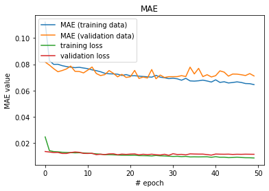

```python
print("[INFO]: Evaluando red neuronal...")
# Datos para el conjunto de entrenamiento para posterior fusion
dnn_predictions_train = model_2.predict(X_train_final)

# Para el conjunto de prueba
dnn_predictions_test = model_2.predict(X_test_final)

test_loss, test_mae = model_2.evaluate(X_test_final, y_df_test_norm)
print('Media del error en datos de test: ' + str(round(test_mae,5)))

plt.plot(H.history['mae'], label='MAE (training data)')
plt.plot(H.history['val_mae'], label='MAE (validation data)')
plt.plot(H.history['loss'], label = 'training loss')
plt.plot(H.history['val_loss'], label = 'validation loss')
plt.title('MAE')
plt.ylabel('MAE value')
plt.xlabel('# epoch')
plt.legend(loc="upper left")
plt.show()
```

## **8. Red Convolucional**

```python
from keras.preprocessing.image import ImageDataGenerator
from keras.models import Model, Sequential
from keras import layers
from keras.layers import Conv2D, MaxPooling2D, Flatten, Dense, Dropout, BatchNormalization, Activation
from keras.constraints import max_norm
```

```python
# Recordemos que sobre las variables que voy a trabajar son:
#   img_train
#   img_test
#   y_df_norm
#   y_df_test_norm

input_shape = (224, 224, 3)

datagen_train = ImageDataGenerator(
    rotation_range=15,
    width_shift_range=0.1,
    height_shift_range=0.1,
    zoom_range=0.1,
    horizontal_flip=True
)

model_img = Sequential()

model_img.add(Conv2D(32, kernel_size=(3, 3), activation = 'relu', input_shape = input_shape))
model_img.add(MaxPooling2D(pool_size = (2, 2)))
model_img.add(Dropout(0.25))

model_img.add(Conv2D(32, kernel_size = (3, 3), activation = 'relu'))
model_img.add(MaxPooling2D(pool_size = (2, 2)))
model_img.add(Dropout(0.25))

model_img.add(Conv2D(32, kernel_size = (3, 3), activation = 'relu'))
model_img.add(MaxPooling2D(pool_size = (2, 2)))
model_img.add(Dropout(0.25))

model_img.add(Flatten())
model_img.add(Dense(32, activation='relu', kernel_constraint=max_norm(3.)))
model_img.add(Dropout(0.5))

model_img.add(Dense(1, activation='linear'))


model_img.compile(loss='mse',
              optimizer=Adam(learning_rate=0.001),
              metrics=['mae'])

epochs = 5
batch_size = 16
train_steps_per_epoch = img_train.shape[0] / batch_size
test_steps_per_epoch = img_test.shape[0] / batch_size

model_img.fit(
    datagen_train.flow(img_train, y_df_norm, batch_size),
    steps_per_epoch = train_steps_per_epoch,
    epochs = epochs,
    validation_data = datagen_train.flow(img_test, y_df_test_norm, batch_size = batch_size),
    validation_steps=test_steps_per_epoch
)
```

```
<keras.callbacks.callbacks.History at 0x2567842e748>
```

## **9. Late-Fusion**

```python
# Datos para el conjunto de entrenamiento para posterior fusion
cnn_predictions_train = model_img.predict(img_train)

# Para el conjunto de prueba
cnn_predictions_test = model_img.predict(img_test)

scores = model_img.evaluate(datagen_train.flow(img_test, y_df_test_norm, batch_size=batch_size),
                            steps=test_steps_per_epoch)

print('Loss: %.3f' % scores[0])
print('MAE: %.3f' % scores[1])
```

```
Loss: 0.046
MAE: 0.126
```

```python
### Combinación de las predicciones ###
fusion_input_train = np.hstack((dnn_predictions_train, cnn_predictions_train))

fusion_input_test = np.hstack((dnn_predictions_test, cnn_predictions_test))
```

```python
print(fusion_input_train.shape,
fusion_input_test.shape)
```

```
(4448, 2) (1060, 2)
```

```python
from sklearn.metrics import mean_squared_error, mean_absolute_error

param_grid = {
    'n_estimators': [100, 200, 300],
    'max_features': ['auto', 'sqrt'],
    'max_depth': [10, 20, None],
    'min_samples_split': [2, 5, 10],
    'min_samples_leaf': [1, 2, 4],
    'bootstrap': [True, False]
}

rf = RandomForestRegressor()

grid_search = GridSearchCV(estimator=rf, param_grid=param_grid, cv=3, n_jobs=-1, verbose=2, scoring='neg_mean_squared_error')
grid_search.fit(fusion_input_train, y_df_norm)

print("Mejores hiperparámetros:", grid_search.best_params_)

best_rf = grid_search.best_estimator_

predictions = best_rf.predict(fusion_input_test)

mse = mean_squared_error(y_df_test_norm, predictions)
mae = mean_absolute_error(y_df_test_norm, predictions)

print(f'MSE: {mse}, MAE: {mae}')
```

```
Fitting 3 folds for each of 324 candidates, totalling 972 fits
```

```
[Parallel(n_jobs=-1)]: Using backend LokyBackend with 8 concurrent workers.
[Parallel(n_jobs=-1)]: Done  25 tasks      | elapsed:    6.3s
[Parallel(n_jobs=-1)]: Done 146 tasks      | elapsed:   22.7s
[Parallel(n_jobs=-1)]: Done 349 tasks      | elapsed:   58.3s
[Parallel(n_jobs=-1)]: Done 632 tasks      | elapsed:  1.8min
[Parallel(n_jobs=-1)]: Done 972 out of 972 | elapsed:  3.2min finished
```

```
Mejores hiperparámetros: {'bootstrap': True, 'max_depth': 10, 'max_features': 'sqrt', 'min_samples_leaf': 2, 'min_samples_split': 2, 'n_estimators': 100}
MSE: 0.010647409818055132, MAE: 0.06950016043317983
```

```python
y_test_denorm = y_scaler.inverse_transform(y_df_test_norm)  # Revertir la normalización
predictions_denorm = y_scaler.inverse_transform(predictions.reshape(-1, 1))  # Revertir la normalización de las predicciones

# MSE y MAE con los valores en la escala original
mse_denorm = mean_squared_error(y_test_denorm, predictions_denorm)
mae_denorm = mean_absolute_error(y_test_denorm, predictions_denorm)

print('MSE (Escala original): %.3f' % mse_denorm)
print('MAE (Escala original): %.2f' % mae_denorm)
```

```
MSE (Escala original): 425.896
MAE (Escala original): 13.90
```

Como conclusión, creo que puedo considerar al modelo fusion bastante bueno, obteniendo como error aproximadamente 14 Euros en la predicción. Como modelo de alta precisión desde luego que está bastante lejos de serlo, sin embargo, como aproximación está bien